# Installation Guide for the CTT SensorStation and CTT Nodes - DRAFT

support@celltracktech.com

6/29/2020

# 1 Congratulations

If you are reading this document, then you most likely have purchased one of our Internet of Wildlife (IoW) components. Whether you’re doing localized detailed studies of small mammals or songbirds, or you’re setting up SensorStations as part of the global Motus Wildlife Tracking System (motus.org), or you’re doing something in-between, we’ve got you covered, and this document is meant to help you get started quickly and painlessly. If for some reason you get stuck along the way, please don’t hesitate to reach out to us directly either via email (support@celltracktech.com) or through our online Help Desk here: https://celltracktech.atlassian.net/servicedesk/customer/portals.

# 2 Participating in the Motus Wildlife Tracking System

If you are setting up your SensorStation to participate in the Motus Wildlife Tracking System (motus.org), your station can still be used with CTT Nodes. In general, we recommend Motus stations to include 4 Yagi 10-element antennas pointing in the 4 cardinal directions. A fifth Omni antenna can be installed and dedicated to detecting nodes, or one of the Yagi antennas can be used for nodes while the other three are positioned at 120 degrees for full coverage. You may also add any number of 166MHz antennas by using a Software Defined Radio (SDR), such as a FunCube or RTL-SDR, via any of the USB ports on the SensorStation (SDRs are sold separately via third-party companies). A clear view of the horizon is preferred to get maximum range, so a height as high as possible is also advised. For more information on Motus, see Appendix 1.

# 3 SensorStation Precautions

Treat your SensorStation board like you would any other motherboard, Arduino or Raspberry Pi. All electronics, no matter how robust, can be static sensitive. Take care no metal objects touch the board while it is operating, such as antenna connectors or GSM antennas, as this could cause electrical shorts that will damage the board. It is advised to wear an anti-static bracelet when handling SensorStation.

[figure not shown]

# 4 Setting up your CTT IoW System

CTT’s Internet of Wildlife System (IoW) is a complete radio telemetry system that consists of transmitters (radio tags), and receivers. Currently CTT produces four radio transmitters: the LifeTag<sup>TM</sup>, PowerTag<sup>TM</sup>, ES-200 and ES-150.

### 4.0.1 LifeTag

The **CTT LifeTag** is 100% solar powered, and therefore has no battery. This allows the tag to persist for many years, beeping out its unique digital ID whenever it has sunlight. For species active during the day, and for small animals for which multi-season or multi-year data are required, LifeTags are the obvious choice.

### 4.0.2 PowerTag

The **CTT PowerTag** is battery powered which means it can beep out its digitally coded ID 24-hours a day. The life span of a PowerTag is defined by the beep rate (# of beeps per minute) and battery size. For species where nighttime data is important, PowerTags are the perfect fit.

### 4.0.3 ES-200 and ES-150

The **ES-200** and **ES-150** are GPS logger tags that can also send data over the 434MHz frequency, and therefore can send archived telemetry data to the SensorStation. Since they communicate on the same frequency as LifeTags and PowerTags, no special radio configuration is needed. The difference between the two is that the ES-150 also has an Argos radio to send data via the Argos satellite network.

### 4.0.4 CTT SensorStation

The **CTT SensorStation** collect data directly from tags and can collect data from a series of Nodes to more precisely locate tags within a study site. The SensorStation stores data and, with an optional GSM data plan, can also send those data directly to the CTT Servers.

### 4.0.5 CTT Node

**CTT Nodes** are essentially *mini-base stations*: devices with integrated solar panels, a lithium battery, and an antenna to collect data from **PowerTags** and **LifeTags** and send those data to the **SensorStation**. These data can then be post-processed to localize tags within a grid of nodes over user-defined time steps.

## 4.1 Understanding Detection Distances

The detection distance **from Node to Tag** varies for various reasons, including terrain, vegetation, and the behavior of the tagged animals. For instance, a bird flying overhead may be picked up over a kilometer away by a node, but one foraging in dense vegetation may only be detected from a few hundred meters. When using nodes for localization it’s important to note that the accuracy of locations of animals wearing tags can be as little as less than 5m, but can range widely depending on the density of Nodes. For localizing tag positions, the spacing and placement of nodes must allow for tags to be detected simultaneously by three or more nodes.

The detection distance from **SensorStation to Node** is also affected by terrain and vegetation, but also antenna height and type (omni-directional vs. directional). **Therefore, while there is no hard and fast rule, a good starting point is to keep your farthest node within 1-1.5km of the SensorStation.** The number of SensorStations needed for each system depends on the size of the study area. For instance, in a 2 KM<sup>2</sup> plot, a SensorStation placed at the center of the plot could detect nodes across the entire study area, in most cases with only an omni-directional antenna. Because Nodes are dependent on the SensorStation to receive their data and aggregate it for analysis, it is critical to ensure each node is within the detection radius of at least one SensorStation at all times.

The detection distance from **SensorStation to Tag** is affected by the same factors as SensorStation to Node, but because many tags are on birds, bats and insects, the relationship between the two objects can change drastically over very short time steps. With line-of-sight, a tag on a bird has been shown to be detectable for **dozens of kilometers** by a SensorStation. On the other hand, birds foraging in dense vegetation may only be detectable by a station within a few kilometers. Therefore, careful consideration of station position with relation to the biological questions being asked is critical for a successful deployment.

## 4.2 SensorStation installation example

### 4.2.1 Materials

- **LifeTag/PowerTag or ES-200**
- **Nodes (each)**
  - 1 x Node box
  - 1 x Antenna
  - 1 x Clamp hardware
  - 1 x ¾” EMT conduit
- **SensorStation**
  - 1 x SensorStation
  - 1 x Enclosure
  - 4 x SensorStation Screws: #8-16 X ¼ phillips self tapping screws for plastic:  
    https://www.mcmaster.com/99461a330
  - 1 x Power cable
  - 1 x Omni Antenna
  - 1 x Coax cable
- **Mounting hardware**
  - 10’ long 1’’ EMT conduit
  - 10’ long 1 ¼’’ EMT conduit
  - 10’ long 1 ½’’ EMT conduit
  - Tripod
  - SensorStation Clamp
  - Tap screws
  - zip ties
  - coax tape
- **Optional**
  - colored electrical tape for color-coding antenna wire ends

### 4.2.2 Mounting your Equipment

For both the SensorStation and Nodes we recommend attaching to **EMT conduit**. We recommend this because it is rigid and easy to set up. This is *not* what’s commonly referred to as *Black Pipe* used for water and gas lines, but the **galvanized steel pipe** used for running electrical wiring inside.

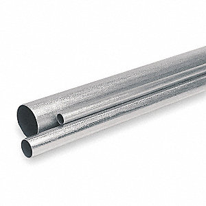

### 4.2.3 Building a mast for your SensorStation

**We don’t recommend PVC** because it moves in the wind, becomes brittle, and will snap over time. EMT can be painted if you would like them camouflaged.

The conduit can be attached to a tripod, mounted directly into the ground, or onto a building or other structure. The Nodes and SensorStations are then attached to the conduit. The diameter of the conduit is typically 1” for the top mast section of the SensorStation (the section to which the antennas are attached; light green in the picture below).

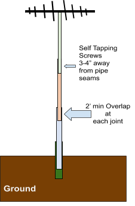

If desired, stainless conduit can be purchased, however it is much more expensive, but **recommended if you are in an area that receives high winds**. It is crucial to overlap each section of pipe by at least 2 feet. **Self tapping screws** are used to hold pipes together, but should not be used within 3-4” of the end of the pipes and/or seams. The chart below should help with what is needed for your setup per SensorStation.

| Total Approx Mast Ht. | EMT Needed for mast (10’) | Ground Section Needed (4’) | Coax Length Per Antenna |
| --- | --- | --- | --- |
| 7’ | 1" | 1 1/4" | min 10ft |
| 15’ | 1”,1 ¼” | 1 ½” | min 20’ |
| 23’ | 1”, 1 ¼”, 1 ½” | 2” | min 25’ |
| 28’ | 1”, 1 ¼”, 1 ½” | 2”- Use full 10’ | min 30’ |

*Masts higher than 28’ not recommended with standard free-standing EMT conduit. Guy wires and/or scaffold or tripod masts are other options for higher towers.*

### 4.2.4 Mounting Nodes

Nodes are typically attached to the top of a ¾” piece of EMT. The clamps shown below come standard with the nodes and accept ¾ or 1” conduit.

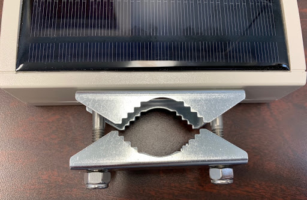

A 7/16” socket is used to tighten the clamp bolts. The EMT is typically driven into the ground approximately 2 feet. The height of the nodes can be changed depending on the project, but for best results should be consistent within a study site. We recommend 8’ for most setups, see below for pictures of the node setup in the field. If you choose an alternate mounting method, care should be taken that they are secure. If they are mounted on anything that sways greatly with the wind, the readings won’t be consistent.

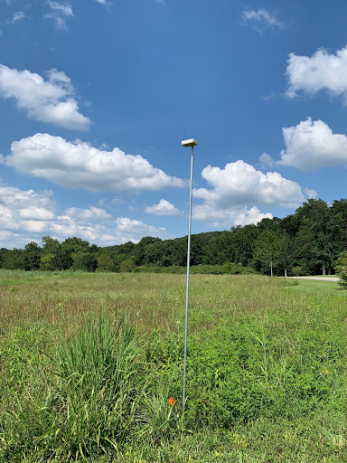

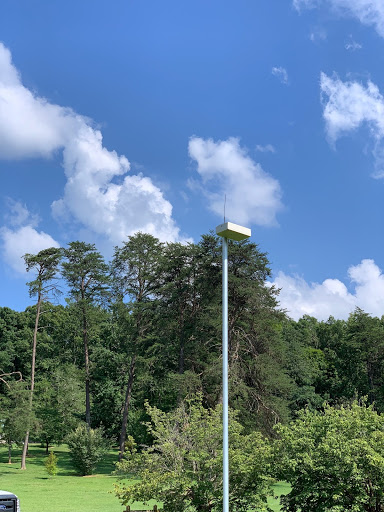

**Note:** *Nodes purchased in 2020 and beyond have a built-in GPS. Prior to 2020 you must take accurate GPS readings and record that data with the Node ID in order to run post-hoc localization analyses.*

## 4.3 Node Placement

Setting up the CTT Nodes is typically done in a grid in your study site. It is not imperative that they are exactly in a grid, but the closer you can set them up in a grid, the more accurate positioning you will get from the tags. In sites where this is not practical, you can simply set them up where you can, 100-300m apart, and record GPS of the Node locations. Even in a grid setup, it is best practice to take GPS coordinates whether or not they differ from the layout.

## 4.4 SensorStation Placement

The CTT IoW SensorStation may be placed anywhere within range of the farthest node, which is typically 1-1.5km (although higher placement of SensorStation antennas, and clear line-of-sight between stations and nodes, can achieve longer detection distances). See the next section on SensorStation Configuration and Antenna Detail for more details on this. It is recommended to place the SensorStation antennas at least 2 meters high. The higher the antennas, the better range you will get.

## 4.5 SensorStation Configuration and Antenna Detail

The standard configuration for the CTT SensorStation allows for receiving data on *five 434MHz* radio ports simultaneously. These can be configured to either record signals from LifeTags/PowerTags and ES-200 GPS loggers (hereafter “tags”), or to collect data from CTT Nodes. *Tags and Nodes cannot be picked up on the same channel*, and how you configure your station depends depends on your study goals. The number of channels necessary on a SensorStation depends on the number of Nodes, whether you want to detect tags/transmitters and/or Nodes directly with the SensorStation, and the distance the Nodes are from the SensorStation.There is no hard limit to the number of nodes that can be detected by a single SensorStation, but it’s best to keep that number around 50 or less. *Distance to the SensorStation will usually be the limiting factor for the number of nodes detectable by a single SensorStation.*

Two types of antennas are commonly used with the SensorStation: *Omnidirectional* and *Yagi*. *Omnidirectional antennas* efficiently receive energy in a *horizontal plane 360 degrees around the SensorStation*. Omnidirectional antennas typically do not have as great a range as Yagis, but a benefit is the 360 degree detection, and great detection of tags and nodes that are near the station.

**Note: Whereas in the past we have recommended specific polarization for omnidirectional antennas picking up Nodes vs. Tags, in our testing we have found the difference negligible and find vertical omni antennas to be much simpler and less expensive for a greater value over horizontally polarized omnis.**

*Yagis are directional antennas* used to detect tags and nodes in a specific direction from the SensorStation. They *typically have a 30-60 degree detection range that extends away from the SensorStation*. For that reason typically 2-4 antennas are used, one pointed in each cardinal direction, or two pointed in opposite directions and used to make a “fence”. Yagis can also be used to pick up Nodes that are farther away from the SensorStation.

While there are many antennas to choose from, these are a few that we can recommend from experience:

- Omni-directional
  - [Data Alliance A433O5](https://www.data-alliance.net/antenna-433mhz-5dbi-omnidirectional-fiberglass-w-n-male-vhf-uhf-marine/)
    - and you’ll need [this bracket](https://www.data-alliance.net/l-mount-for-antenna-pole-or-wall-mount-hole-for-n-female-or-rp-sma/)
    - and [this adapter](https://www.data-alliance.net/n-type-female-to-female-coupler-adapter-w-o-ring-weatherproof-bulkhead/)
- Yagi
  - [M2Inc 440-6SS](https://www.m2inc.com/FG4406SS)
  - [Laird YS4306](https://www.mouser.com/ProductDetail/Laird-Connectivity/YS4306?qs=EU6FO9ffTwelQ7%2FXOHiHew%3D%3D)
  - [Diamond A430S10](https://www.hamradio.com/detail.cfm?pid=H0-005816)
  - [Diamond A430S15](https://www.dxengineering.com/parts/dmn-a430s15) *for specialized applications where longer-range is required

**Whatever you choose, make sure you get the proper coaxial end to connect your antenna to your SensorStation!**

### 4.5.1 Mounting the antennas

Antennas are attached to the EMT conduit with the clamps that come with the antennas. If you have a setup that uses 4 yagis, than you will attach the yagis to a 4 or 5-way mounting “hat” you can purchase via online retailers. Once the antennas are on EMT, attach the coax and wrap the connection with coax tape. Run down the poles to where it will attach to the SensorStation. You can use zip ties to secure the coax to poles where needed. Make sure you have enough coax to form a drip loop for each connection.

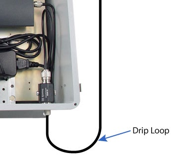

### 4.5.2 Placing your SensorStation

The SensorStation can be placed inside a building, or fastened to the pole or building, etc. It should either be close to the ground for easy access, or have an ethernet cable run down to an accessible location.

# 5 Operating your SensorStation with a solar panel and 12V Battery

The SensorStation can be connected directly to a 12V DC power source, or via a charge controller. Typical setup would be a 50-100W solar panel connected to a charge controller. The charge controller typically has 3 ports. The 3 ports are 1.) Solar panel 2.) 12V battery 3.) Accessory/Device/consumer- which is whatever you are powering- in this case your SensorStation. That line goes into the green *Power In* terminal on the SensorStation board. The positive and negative wire ports are labeled on the board, and to insert the wire simply loosen the set screws on the top, and slide the wire leads in to the holes just under the set screws (see the pictures below).

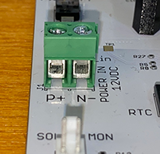

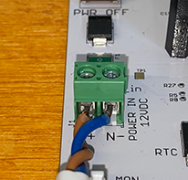

The ends of the wires that are attached should be tinned with solder for best results. If you do not have access to a soldering gun, twisting the ends of the cables tightly will help them slide in cleanly to the power block.

## 5.1 Monitoring your solar voltage

If you would like to monitor your solar voltage remotely, you will need to use the solar monitor connector. it is located above the on/off switch. Simply run two wires from the solar input of the charge controller to a two pin connector.

# 6 SensorStation LEDs

There are several LED lights on the SensorStation which may assist you in diagnosing issues. Note that with the introduction of the SensorStation V2’s LCD screen, all diagnoses can be carried out via the lCD.

- **Diagnostic A** (green) - When blinks it means the software reading the data from the radios is writing it to disk (the system is working). If solid on or off, it indicates that the software has stopped running and is no longer writing data.
- **Diagnostic B** (red) - On when SensorStation has established a point-to-point connection with the on-board modem. It checks every second for a connection. The PPP connection is just the layer that allows the modem to communicate to the network it is on, but doens’t always indicate that the connection is working (in the case of a very weak signal).

## 6.1 Blue GSM Cellular LED

The blue LED by the cellular module, labeled D9, is called the Netlight. The Netlight blinks differently, depending on the modem state. You can use this blink rate to identify if your SensorStation is connected to the Internet or unable to connect.

[output not shown]

# 7 SensorStation Navigation Buttons

The SensorStation features 4 navigation buttons labeled `UP`, `DN`, `BACK` and `SELECT`. They are typically used with the SensorStation software to navigate the LCD display.

## 7.1 Technical Description

These buttons are directly wired to the Compute Module’s GPIO lines BCM4, 5, 6, and 7. You will need to enable pullups on these lines to use these buttons.

# 8 SensorStation LCD Menu

- `File Transfer`
  - `Mount USB` - mounts a properly formatted (FAT-32 or MS-DOS) USB drive to the SensorStation.
  - `Unmount USB` - un-mounts a properly formatted (FAT-32 or MS-DOS) USB drive from the SensorStation. This should be used before removing a USB drive from your SensorStation.
  - `Download` - downloads all data on the SensorStation to the mounted USB drive.
  - `Get WiFi` - loads WiFi credentials from JSON document located in `wifi` folder on mounted USB drive (see **Connecting your SensorStation to a local wireless network** below).
- `System`
  - `About`
    - `Image` - provides the image creation date, and the date of last update.
    - `Ids` - displays the `System Ids` which include the `SensorStation serial number` `SIM number` `Broadcom chip id` and `Raspberry Pi serial number`
    - `Memory` - displays the amount of used memory and the total disk size.
    - `Uptime` - Displays the total up time since the station was last rebooted.
  - `QAQC` - this is an internal function which will eventually be useful to the end-user but not as of this printing.
  - `Time` - The three clocks on the SensorStation, refreshing every two seconds. `r`eal time clock, `g`ps clock and `s`ystem clock.
  - `Restart` - Triggers a system restart.
- `Network`
  - `Cellular`
    - `Ids` - - Displays the SIM ID, the IMEI, and the name of the Modem
    - `Carrier` - Displays the cellular carrier name and signal strength of the connection, refreshing every 2 seconds. This may be useful when troubleshooting problematic GSM connections, and aiming an external cellular antenna (not included).
  - `Ping` - This will ping a known web address to determine whether an internet connection is present. If present, it will return **connected**.
  - `Hostname` - Typically this is `sensorstation.local` and can be used to reach your station when it is connected to WiFi, a local network via Ethernet, or directly to a computer via Ethernet. Once connected, simply navigate to http://sensorstation.local in your web browser to access the SensorStation interface.
  - `IP Address` - Displays the port of connection and IP address assigned to the SensorStation. You can use the IP address to connect to your SensorStation using the same process outlined above under `Hostname`. For example, if the IP Address was 10.1.10.17, typing `http://10.1.10.17` into your web browser’s URL field would bring up the SensorStation web interface.
- `Server` - causes the SensorStation to force a check-in to the CTT hardware server. Requires that the SensorStation is connected to the internet via either GSM, WiFi or Ethernet. Note that this process may take a long time depending on connection speed and/or amount of data being sent/received.
- `Power` - Provides voltages for `Battery` (which represents whatever power source is connected to your SensorStation), `RTC` or Real Time Clock, the coin cell battery on the board, and `Solar` if you have connected a solar monitoring cable from the charge controller to the SensorStation board.
- `Temperature` - Provides the temperature of the SensorStation board. Note temperature will usually be higher than ambient when the board is powered.
- `Location` - provides the Lat/Long for the SensorStation from the on-board GPS.
- `LED` - allows you to select various LED and toggle them `on`, `off` or `blink`.
  - `Diagnostic A` - this LED represents the connectivity to CTT servers.
    - `On` - Turns the LED `on`, if current state is `off`.
    - `Off` - Turns the LED `off`, if current state is `on`.
    - `Blink` - Blinks the LED once.
  - `Diagnostic B` - this LED represents the connectivity to the cellular network (if a cell modem is installed).
    - `On` - Turns the LED `on`, if current state is `off`.
    - `Off` - Turns the LED `off`, if current state is `on`.
    - `Blink` - Blinks the LED once.
  - `GPS` - this green LED has three states: Solid (3D Fix), Blinking 2x/second (2D fix), Blinking 5x/second (No Fix).
    - `On` - Turns the LED `on`, if current state is `off`.
    - `Off` - Turns the LED `off`, if current state is `on`.
    - `Blink` - Blinks the LED once.

# 9 Downloading your data via a USB Thumb Drive

1. Insert a properly formatted (currently only MS DOS or Fat32 formatting is supported) USB thumb drive in one of the seven USB ports.
2. Navigate to `File Transfer > Mount USB` and press the `SELECT` button. You should see a confirmation message saying `USB Mount:success`.
3. Use the `BACK` button to go up to the `File Transfer` menu, and select `Download`. A successful download will be followed by a success message.
4. Use the `Back` button to go up to the `File Transfer` menu and select `Unmount USB`. Once you receive the success message you may remove the USB drive from the SensorStation which will now contain a copy of all the files from the station.

## 9.1 What’s in the folder?

And two folders:

- `SGData` - contains any 166MHz data collected by your station.
- `uploaded` - contains any 434MHz data that has been previously uploaded to CTT servers.

# 10 The SensorStation Web Interface

## 10.1 Overview

### 10.1.1 Nodes

This is a list of Nodes the station has detected since connecting. For each Node it lists:

`Node ID` `Last Heard` - the time of the last health report `Node RSSI` - the RSSI of the Node signal in decibels `Battery Voltage` - the Node’s battery voltage, which can be used to estimate its remaining life. 4.2 V is very full. 3.5 Vis low. 3 V is nearly empty. `Node Firmware Version`

### 10.1.2 Tags

This is a list of unique LifeTags that have been detected by your radios. For each tag it lists

- `Tag ID`
- `Count` - number of beeps since last page refresh
- `Alias` - for convenience, a name can be given to a particular tag and saved in the browser by hitting the `Update` button. This information is saved in your browser only. Name it whatever you’d like. Great for keeping track of particular tags during a test.
- `“Update” Button` - save the name of a particular tag to your browser
- `“Remove” Button` - reset the saved name

### 10.1.3 Station

Various information about your SensorStation is stored here.

- `ID` - the serial number of your SensorStation (the cell modem’s IMEI)
- `Compute Module Serial` - the serial number of your Raspberry Pi Compute Module
- `Module Hardware` - the compute module’s hardware version
- `Module Revision` - the compute module’s hardware revision
- `Boot Count` - the number of times the system has been booted
- `Total Memory` - the amount of RAM currently being used by the system
- `Last Boot` - Datetime of last boot
- `Memory Usage` - A pie chart indicating the amount of system RAM currently being used.
- `CPU Usage` - A pie chart indicating the amount of processing power currently being used.
- `Tag Histogram` - A histogram of tags detected since opening the interface. The bars indicate the number of beeps detected.
- `Time Sync Stats` - Detailed information of how the system time is being retrieved synced (e.g. from GPS or the internet)

### 10.1.4 SensorStation Log

A log of SensorStation activity. Includes things such as screen updates and data retrieval flushes.

### 10.1.5 GPS

Information retrieved over GPS: Time, Satellites, Latitude, Longitude, Altitude. If there is currently no valid fix, these fields will be blank.

### 10.1.6 Radios (1-5)

There is a display box for each Radio port. The boxes will display all new data from each Radio port as they are detected, informing you of the following:

- `Time`
- `Tag ID`
- `RSSI`
- `Node`from which it came (if applicable).

#### 10.1.6.1 Port configuration

Each radio can be individually configured to receive `Nodes`, `Tags (FSK)`, or `OOK (legacy tags)` by clicking the corresponding button. On V1 SensorStations this configuration will only persist until the next webpage refresh unless you press the “Save Radio Configuration” button below, which will save the configuration permanently to memory. For V2 SensorStations the setting is automatically saved as soon as you acknowledge the confirmation popup after clicking the `Node`, `Tag` or `OOK` buttons for a particular radio. Configurations can be changed at any time.

`Clear Session Data` simply clears the scrolling log of tags displayed for each radio port. It does not delete any data from system memory.

### 10.1.7 Data Management

The data management section is the interface through which your station data is retrieved and deleted.

#### 10.1.7.1 Station Log

Allows you to **download** (`Download Log File`) and **PERMANENTLY DELETE** (`Clear Log File`) the system log file. Used for informational and debugging purposes.

#### 10.1.7.2 CTT Tag Data

The tag data is divided into `Current Data`, `Data Not Uploaded`, and `Data Already Uploaded`. Current Data is data from the last 30 minutes. After 30 minutes, data is rotated into Data Not Uploaded, which is data beyond the last 30 minutes which has not yet been uploaded to CTT servers. If there is an internet connection via cell or ethernet, an upload attempt occurs every 2 hours. After data is uploaded, it is rotated into `Data Already Uploaded` and will stay there until you explicitly delete it. The red Delete buttons will **PERMANENTLY DELETE** the corresponding data from the SensorStation. An *are you sure* dialogue will make sure you do not accidentally delete data.

#### 10.1.7.3 Nanotag Data

Nanotag Data uses the same scheme as CTT Tag Data, except that currently data from the last 30 minutes is unavailable from this screen. The Sensorgnome interface is separately accessible as described below.

### 10.1.8 Nanotag Data / Sensorgnome Interface

#### 10.1.8.1 Sensorgnome Interface

Click the “Sensorgnome Interface” button to go to the Sensorgnome interface.

#### 10.1.8.2 Sensorgnome Deployment File

The Sensorgnome Deployment file can be edited here and saved by clicked `Save Changes`.

### 10.1.9 Reboot Button

Reboots the system.

## 10.2 Connecting to the SensorStation Web Interface via Ethernet

### 10.2.1 Before you get started you will need…

- 2 USB to Ethernet adapters (we recommend: https://tinyurl.com/yc6llze4)
- An Ethernet cable

## 10.3 Connecting to the SensorStation Web Interface via Local Wireless Network

You can connect your SensorStation to a local wireless network with a few simple steps.

### 10.3.1 Before you get started you will need…

- WiFi adapter Like this one: https://store.celltracktech.com/products/wifi-usb-adapter-add-on-for-sensorstation-v2.
- Properly formatted USB thumb drive (Fat-32 or MS-DOS formatting currently supported).
- A code editor where you can control the programming language and line encoding. We recommend the free Visual Studio Code (https://code.visualstudio.com).

### 10.3.2 Creating the JSON file

1. In your code editor, create a new file and set the **Language Mode** to `JSON` and the **End of Line Sequence** to **LF** (for Line Feed).
2. Type the following into the file:

```
  {
    "ssid":"my_ssid",
    "psk":"my_password"
  }
```

**Make sure you change “my_ssid” to the name of your wifi network and “my_password” to the password for your wifi network!**

3. Save the file and name it `credentials.json`.
4. Create an empty folder on your USB thumb drive called `wifi`.
5. Copy `credentials.json` file to the `wifi` folder.

### 10.3.3 Loading the JSON file onto your SensorStation

1. Make sure your SensorStation is powered on and the menu is visible on the LCD screen
2. Insert your USB thumb drive into any of the USB ports on your SensorStation.
3. Using the four buttons right of the LCD screen, navigate to `File Transfer > Mount USB` and click the `Select` button.
4. You should receive a `success` message.
5. Now navigate to `File Transfer > Get WiFi` and click the `Select` button.
6. You should receive a `success` message.
7. Restart your SensorStation.
8. After restart, your SensorStation should be connected to your local wifi network. You can test this connection through several diagnostics in the LCD menu.
- `Network > Ping` will indicate a connection.
- `Network > IP Address` will display a valid IP address.

### 10.3.4 Connecting to your wifi-enabled SensorStation

Once your station has connected to your wifi network, you can connect to your SensorStation wirelessly via any device on the **same wifi network** as the station.

- Connect your computer, tablet or smartphone to the same wifi network as your SensorStation.
- open a web browser on your computer, tablet or smartphone and navigate to the IP address found via the `Network > IP Address` on your SensorStation’s LCD screen. Alternatively you can use the name found in `Network > Hostname`, which is typically `sensorstation.local`.

## 10.4 Programming Radios

Your five 434MHz radios will typically arrive pre-configured to detect tags. You can see the configuration for each radio displayed on the web interface. Changing the programming is as simple as clicking the appropriate button. Click `Node` for detecting nodes or `Tag` for detecting LifeTags, PowerTags or ES-200 devices. The `OOK` tag is a specific legacy tag type only used on a few projects. **Note that once you have changed the radio settings, the change is immediately saved and the data will flow from whichever you changed it to; node or tag, but in order to see the text description change on the web interface, you will need to refresh the webpage.**

## 10.5 Managing your SensorStation from the Web Interface Server Utilities

From the Server Utilities section on the web interface, you can now `Update Your SensorStation` to the latest deployment build, as well as force `Check In` and force `Upload Data` to the CTT servers.

**Requirement:**

- Because these buttons require connecting to servers via the internet, your SensorStation must be connected to the internet, either via the *on-board LTE module*, hardwired via *Ethernet* (this includes being connected to a computer via Ethernet which is connected to the internet), or wirelessly via a *WiFi adapter*.

### 10.5.1 Updating your SensorStation

1. With the CTT Sensor Station Overview page open in your browser, scroll down to `Server Utilities` on the right sidebar.
2. Click the button labeled `Station Update`, which will open the `Sensor Station Software Updater` console
3. Scroll down below the console window and click on the `Update Station` button. This will begin the update process. Be aware that the station will be pulling code from five different code bases, which may take up to several minutes depending on your connection speed.
4. When the process is complete, you will receive a `Station connection disconnected` dialogue. **This indicates that the update is complete** and that the system has restarted. You may now click the dialogue to clear it, and then click the button at the bottom of the screen to go `Back to Main Interface`.

# 11 Troubleshooting

**I get an error when I attempt to mount my USB drive**

*Your USB drive may not be formatted properly*

**I have successfully mounted my USB drive but when I go to `Add Wifi` I get an error**

*Either your USB drive is not formatted properly (some formats will allow you to mount, but not to read the file, such as X-Fat on Mac)* **or** *your JSON file is not properly formatted.*

- Verify the following:
  - Your file is named `credentials.json`
  - Your file is in a folder called `wifi`
  - There is only one folder called `wifi` on your USB thumb drive
  - Your JSON file was created with the End of Line Sequence set to **LF**
  - Your JSON file was properly formatted (see **#2** under **Creating the JSON file** above)
  - Note you can always check your code validity by pasting it into this website: https://jsonlint.com and clicking `Validate JSON`

# 12 Known Bugs

1. SensorStations without a modem installed will not check in to the CTT system.

# 13 Appendix I: Leveraging your CTT Infrastructure with Motus

[figure not shown]

[figure not shown]

[figure not shown]

## 13.1 The Motus Wildlife Tracking System

When tracking wildlife with automated radio telemetry over vast distances, the challenge of deploying enough receivers to get detections grows exponentially. To remedy this, data can be shared between all researchers so that essentially everyone is sharing receivers. This greatly expands the potential for this technology, but it comes with the added responsibility of coordinating projects, detection data and metadata - that’s where Motus comes in.

## 13.2 What is Motus?

The Motus Wildlife Tracking System is an international collaborative network of researchers that use automated radio telemetry to simultaneously track hundreds of individuals of numerous species of birds, bats, and insects. The system enables a community of researchers, educators, organizations, and citizens to undertake impactful research and education on the ecology and conservation of migratory animals. When compared to other technologies, automated radio telemetry currently allows researchers to track the smallest animals possible, with high temporal and geographic precision, over great distances.

## 13.3 How does Motus work?

The entire philosophy behind Motus is that we’re all working together. At its core, Motus is community science. A community of researchers around the world conducting research on animals are tracked by a network of receiving stations maintained by a community of researchers, organizations, non-profits, governments, and individuals. In order for this concept to work, the system requires a centralized database and management system that all participants use. Most importantly, in order for your tags to be detected on any other station in the network, or for other project tags to be detected elsewhere, projects, receivers and tags need to be registered with, and have data processed by Motus.

While any automated telemetry project can operate in isolation, operating as a Motus project combines the collective impact of local, regional, and even hemispheric projects into one massive collaborative effort that expands the scale and scope of everyone’s work and maximizes the use of scarce research dollars. It also makes data available and more useful for future projects, collaborative endeavors and large-scale meta analyses.

## 13.4 What’s the cost?

There is NO cost to register your project and receivers to the Motus network and contribute your data. Tags registered to the network are charged a nominal fee to support data processing and ongoing maintenance and development of the system. See the collaboration policy and fee schedule for more information.

## 13.5 Data Ownership/Privacy

The collaborative nature of Motus relies on a certain level of transparency with respect to data. While basic project and tag summary information is made publicly available, researchers have the ability to customize data accessibility and keep their project and data private if necessary. See the collaboration policy for more information.

## 13.6 How to join Motus? *In 3 or 5 easy steps*

1. [Register with Motus](https://motus.org/data/user/new)
2. **Create your Project.** Once registered with Motus you can join an existing project, or if registered as a Principal Investigator, you can create your own project. Manage landowners, users, data access levels, and project descriptions.
3. **Register and manage your Receivers.** Enter and update important metadata about your receiver and station configuration, and upload data.
4. *(Optional)* Register your Tags. Enter and update important metadata about your tags and animals.
5. *(Optional)* Explore your data. Use our online resources to explore your data, or download and begin to analyze your data using the Motus R Book.

## 13.7 Motus provides

### 13.7.1 Collaboration and Community

- Coordinated global network of automated radio telemetry receivers. See Motus by the numbers.
- Become part of a global research and conservation community.
- Collaborators have full control over data access.
- Projects can be designed based on the placement of third-party stations.
- Tagging data from multiple projects can be utilized in large-scale studies.
- Troubleshooting and consultation advice from other researchers in the community, Motus staff and technology partners.

### 13.7.2 Data archive and management

- One centralized data hub at Birds Canada National Data Center.
- Standardized data format across all projects.
- Permanent archive of data.
- Access to the research software platform data visualization and management tools.
- Metadata management platform.
- Combined data from multiple stations into one simple to use database accessible through R.
- Import data to Movebank.

### 13.7.3 Data access

- Data is available from all stations in the network as soon as it is uploaded.
- Real-time data uploads for stations with internet connectivity
- Automatic data streaming from the receiver to Motus.org.
- Public access to station and tag summary data, tracks, and maps via Motus.org.

### 13.7.4 Data Analysis and Tools

- All data is automatically packaged and available in real-time through the Motus R Package.
- Opportunities to Join a community of scientists developing new code for data processing, modeling, and manipulation.
- Motus Research Software Platform visualization tools.

### 13.7.5 Technology

- Draw on a community Supports options for local-to-hemispheric tracking infrastructure.
- Partnerships with multiple technology firms for receivers and tags across numerous cutting-edge technologies.
- Open-source hardware and software solutions via sensorgnome.org.

## 13.8 Motus is advancing

- **Multi-disciplinary Science**
  - Movement, migration, and population ecology
  - Animal behavior and physiology
  - Environmental management
- **Conservation**
  - Populations, survival, and species dynamics
  - Stopover, site-based, and full life-cycle knowledge
  - Informing use of flyways and landscapes
- **Education**
  - Undergraduate through postgraduate studies
  - Open framework for development, code, and analysis sharing
  - Grade X-12 STEM curricula (science, technology, engineering, math)
- **Public engagement and storytelling**
  - Visit https://motus.org/education

We are welcoming new collaborators and supporters each week! **For more information or discuss how you or your organization can support Motus, contact motus@birdscanada.org**

# 14 Appendix II: Qickstart Guide

## 14.1 Powering up your SensorStation

1. Ensure your station is in the `OFF` power position.
2. If you purchased your SensorStation complete with a case and AD/DC power block, simply plug in your SensorStation and turn the on/off switch to `ON`.
3. Otherwise, follow the directions under **Connecting your SensorStation with a solar panel to a 12v Battery**

## 14.2 Connecting antennas

To connect antennas to your SensorStation you will need coaxial cable (we recommend LMR-400 or better) with the proper ends to connect to the antenna (manufacturer specific) and your SensorStation. If connecting directly to the board, each 434MHz radio has a **SMA Female** port, so your coaxial will require an **SMA Male** connector.

If connecting to our NEMA case, your coaxial will need a **Type N Male connector**.

If connecting an antenna for a different frequency, such as 166MHz, you will need to attach your Software Defined Radio (SDR) to one of the USB ports and your coaxial cable to the SMA connector on the SDR. Note that any 166MHz radios will only show up in the SensorGnome section of the Web Interface (see **Sensor Station Web Interface**).